# Tarea 1 - Probabilidad y Estadística

## OBJETIVO

1. Identificar variables aleatorias comunes y sus distribuciones en contextos dados
2. Aplicar propiedades de la probabilidad para resolver problemas
3. Identificar comandos de R para el cálculo de probabilidades
4. Analizar la forma de las funciones de probabilidad (o densidad) de variables aleatorias comunes
5. Crear archivos RMarkdown

## INSTRUCCIONES

1. Identifique la variable aleatoria y distribución que resuelve cada uno de los problemas planteados
2. Resuelva los ejercicios utilizando R
3. Escriba sus respuestas en un archivo R Markdown
4. Envíe en html sus respuestas al apartado correspondiente en el grupo de Teams

## Ejercicio 1

Se convocaron a estudiantes de enfermería y al público en general para registrarse y apoyar como voluntario en los puestos de vacunación contra covid. Si 7 de cada 10 voluntarios son estudiantes de enfermería:

En este caso la variable aleatoria seria si la persona voluntariada es un estudiante de enfermeria o alguien del público en general (v.a. d.c.:Bernoulli).

1. Calcule la probabilidad de que se necesiten 40 voluntarios registrados para completar 20 estudiantes de enfermería.

Experimento: registro de voluntariado. Espacio muestral: {estudiante de enfermeria(exito/1), publico general(fracaso/0)}. Probabilidad de exito: 7/10. Variable aleatoria: discreta comun binomial. Comando en R para su funcion de probabilidad: “dbinom(x,n,p)” donde x=cantidad de exitos, n=ensayos de Bernoulli, p=probabilidad de exito.

Evento 1: 40 voluntarios(ensayos) para 20 estudiantes(exitos).

```r
x=20
n=40
p=7/10
dbinom(x,n,p)
```

```
## [1] 0.003835144
```

**Teniendo una probabilidad aproximada de 0.38%**

2. Calcule la probabilidad de que se necesiten 30 voluntarios registrados para completar 20 estudiantes de enfermería.

Evento 2: 30 voluntarios(ensayos) para 20 estudiantes(exitos).

```r
x=20
n=30
p=7/10
dbinom(x,n,p)
```

```
## [1] 0.1415617
```

**Teniendo una probabilidad aproximada de 14.16%**

3. Grafique la función de probabilidad (o densidad) utilizada

Solo es cuestion de utilizar la funcion de plot que se tiene para R, usando de argumento para cada elemento de las abscisas, la cantidad de Voluntariados, y en las ordenadas el resultado de la probabilidad de exito que se 20 exitos(X)

**Resultando en la grafica:**

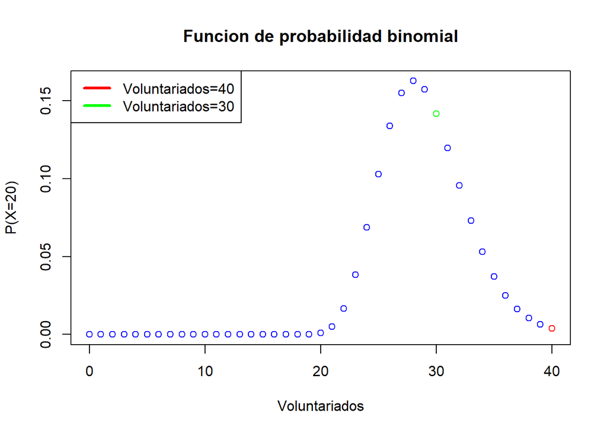

```r
x=20
n1=40 # n del evento 1 (Voluntariados)
n2=30 # n del evento 2 (Voluntariados)
n<-seq(0,max(n1,n2),1)
p=0.7

plot(n,dbinom(x,n,p),main = "Funcion de probabilidad binomial",ylab = "P(X=20)", xlab = "Voluntariados",col="blue")
points(n1,dbinom(x,n1,p),col="red")
points(n2,dbinom(x,n2,p),col="green")
legend("topleft", legend = c(paste0("Voluntariados=",n1),paste0("Voluntariados=",n2)),lwd = 3, col = c("red", "green"))
```

## Ejercicio 2

Los precios nacionales por arrendamiento de tanques con oxígeno medicinal con capacidad para 10,000 litros de oxígeno, tan demandados durante la contingencia sanitaria por covid, tienen una media de MX$1177 y una desviación estándar de MX$972. Si se elige una muestra de 40 tanques:

1. Aproxime la probabilidad de que la media muestral de sus precios se encuentre entre MX$1000 y MX$1200 pesos.

Experimento: consultar el precio del tanque de oxigeno. Espacio muestral: {Numeros positivos}. Variable aleatoria: continua comun normal. $ds=\frac{\sigma}{\sqrt{n}}=\frac{972}{\sqrt{40}},$ $\mu=1177$. Comando en R para su funcion de probabilidad: “dnorm(x,ds,md)” donde x=media muestral, ds=desviacion estandar, md=media.

Evento 1: Valor entre 1200 y 1000.

```r
n=40
md=1177
ds=972/sqrt(n)
b=1200
a=1000
p=pnorm(b,md,ds)-pnorm(a,md,ds) #F(a<=x<=b)=F(b)-F(a)
print(p)
```

```
## [1] 0.4347582
```

**Teniendo una probabilidad aproximada de 43.48%**

2. Grafique la función de probabilidad (o densidad) utilizada.

Solo es cuestion de utilizar la funcion de plot que se tiene para R, usando de argumento para cada elemento de las abscisas, la media muestral de sus precios, y en las ordenadas el resultado de su probabilidad

**Resultando en la grafica:**

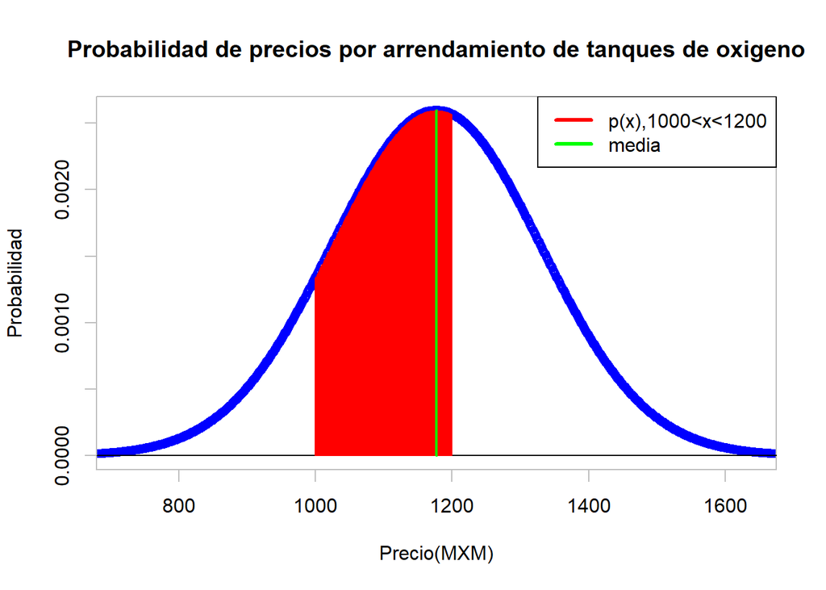

```r
n=40
md=1177
ds=972/sqrt(n)
ran=md-4 # Como la 68% de los datos son entre +-\1sigma,95% para +-2, 99% para +-3\sigma, entonces utilizamos el rango
x<-seq(1,2000,1)

plot(x,dnorm(x,md,ds),main = "Probabilidad de precios por arrendamiento de tanques de oxigeno",ylab = "Probabilidad", xlab = "Precio(MXM)",col="blue",xlim=c(md-3*ds,md+3*ds),fg = "gray")
abline(h = 0)
x<-seq(1000,1200,1)
lines(x,dnorm(x,md,ds),type="h",col="red")
lines(md,dnorm(md,md,ds),type="h",col="green",lwd=2)
legend("topright", legend = c("p(x),1000<x<1200", "media"),lwd = 3, col = c("red", "green"))
```

## Ejercicio 3

Ante la demanda ocasionada por la pandemia de covid, se realizó una investigación de los precios por recargas de oxígeno medicinal en cilindros con capacidad para 10,000 litros de oxígeno. Si el precio ofrecido por los proveedores nacionales sigue una distribución normal con media de MX$731$ y desviación estándar de MX$175$:

1. Calcule el porcentaje de tanques cuyo precio oscila entre MX$600 y MX$700.

Experimento: consultar el precio de recargas de oxígeno medicinal en cilindros. Espacio muestral: {Numeros positivos}. Variable aleatoria: continua comun normal. $ds=\sigma=175,$ $\mu=731$. Comando en R para su funcion de densidad: “pnorm(x,ds,md)” donde x=media muestral, ds=desviacion estandar, md=media.

Evento 1: Valor oscilando entre 600 y 700.

```r
md=731
ds=175
b=700
a=600
pnorm(b,md,ds)-pnorm(a,md,ds)
```

```
## [1] 0.2026403
```

**Teniendo una probabilidad aproximada de 20.26%**

2. Calcule el porcentaje de tanques cuyo precio es de al menos MX$800.

Evento 2: Valor al menos de 800.

```r
md=731
ds=175
x=800
1-pnorm(x,md,ds)
```

```
## [1] 0.3466851
```

**Teniendo una probabilidad aproximada de 34.67%**

3. Grafique la función de probabilidad (o densidad) utilizada.

Solo es cuestion de utilizar la funcion de plot que se tiene para R, usando de argumento para cada elemento de las abscisas, el precio, y en las ordenadas la probabilidad

**Resultando en la grafica:**

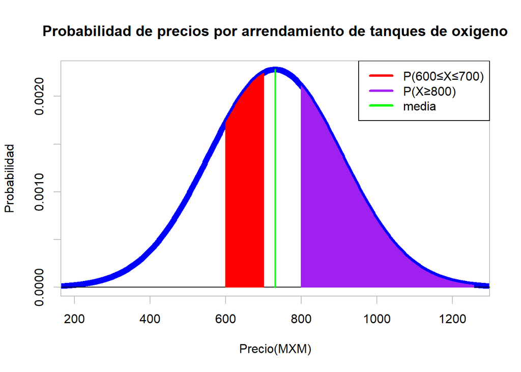

```r
n=40
md=731
ds=175
#Ejercicio1
a1=600
b1=700
#Ejercicio2
a2=800
xmax=md+3*ds # Como la 68% de los datos son entre +-\1sigma,95% para +-2, 99% para +-3\sigma, entonces utilizamos el rango

x<-seq(1,xmax+100,1)

plot(x,dnorm(x,md,ds),main = "Probabilidad de precios por arrendamiento de tanques de oxigeno",ylab = "Probabilidad", xlab = "Precio(MXM)",col="blue",xlim=c(md-3*ds,md+3*ds),fg = "gray")
abline(h = 0)
# Ejercicio 1
x<-seq(a1,b1,1)
lines(x,dnorm(x,md,ds),type="h",col="red")
# Ejercicio 2
x<-seq(a2,xmax,1)
lines(x,dnorm(x,md,ds),type="h",col="purple")
# Media
lines(md,dnorm(md,md,ds),type="h",col="green",lwd=2)
# Simbologia
legend("topright", legend = c(paste0("P(",a1,"≤X≤",b1,")"),paste0("P(X≥",a2,")"),"media"),lwd = 3, col = c("red","purple","green"))
```

## Ejercicio 4

El primer filtro en un puesto de vacunación contra covid, consiste en preguntar a las personas si han presentado en la última semana alguno de los síntomas asociados a la enfermedad como tos y fiebre. Si alguna persona ha presentado al menos uno de estos síntomas, se le invita a pasar a responder un cuestionario más detallado con profesionales de la salud para decidir si es conveniente vacunarlo o no. Si de registros previos se sabe que el 97% de las personas que acuden a vacunarse no han presentado síntomas en la última semana:

1. Calcule la probabilidad de que se necesiten encuestar a 100 personas para encontrar a la primera que pasará a responder el cuestionario detallado.

Experimento: si la persona muestra sintomas. Espacio muestral: {Presentar sintomas(1/exito), no presentarlos(0/fallo)}. Probabilidad de exito: 3%. Variable aleatoria: comun discreta geometrica. Comando en R para su funcion de densidad: “dgeom(n,p)” donde n=fracasos antes del exito, p=probabilidad.

Evento 1: Se necesite 100 personas (99 fracasos, 1 exito).

```r
n=100
p=0.03
dgeom(n-1,p) # Restando 1, ya que en R no se incluye el exito en la X, a diferencia de algunos libros y autores
```

```
## [1] 0.001470696
```

**Teniendo una probabilidad aproximada de 00.15%**

2. Calcule la probabilidad de que la 50° persona sea la primera que pasará a responder el cuestionario detallado.

Evento 2: Se necesite 50 personas (49 fracasos, 1 exito).

```r
n=50
p=0.03
dgeom(n-1,p) # Restando 1, ya que en R no se incluye el exito en la X, a diferencia de algunos libros y autores
```

```
## [1] 0.00674429
```

**Teniendo una probabilidad aproximada de 00.67%**

3. Calcule la probabilidad de que la primera persona encuestada sea la primera que pasará a responder el cuestionario detallado.

Evento 3: Se necesite 1 personas (0 fracasos, 1 exito).

```r
n=1
p=0.03
dgeom(n-1,p) # Restando 1, ya que en R no se incluye el exito en la X, a diferencia de algunos libros y autores
```

```
## [1] 0.03
```

**Teniendo una probabilidad aproximada de 3%**

4. Grafique la función de probabilidad (o densidad) utilizada.

**Grafica:**

[figure not shown]

```r
n1=100
n2=50
n3=1
p=0.03
x<-seq(1,max(n1,n2,n3),1)

plot(x,dgeom(x-1,p),main = "Funcion de densidad normal",ylab = "P(X = x)", xlab = "Precio",col="blue")
#Ejercicio 1
points(n1,dgeom(n1-1,p),col="red",lwd=3)
#Ejercicio 2
points(n2,dgeom(n2-1,p),col="purple",lwd=3)
#Ejercicio 3
points(n3,dgeom(n3-1,p),col="cyan",lwd=3)
# Simbologia
legend("topright", legend = c(paste0("Inciso 1, n = ",n1),paste0("Inciso 2, n = ",n2),paste0("Inciso 3, n = ",n3)),lwd = 3, col = c("red","purple","cyan"))
```

## Ejercicio 5

Durante el proceso de vacunación contra covid, se aplicaron en cierto centro de salud 100 vacunas de la marca Moderna, y 200 de la marca Pfizer. Si de las 300 personas vacunadas se selecciona una muestra de 15, y se les contacta por teléfono para dar seguimiento e investigar las posibles reacciones provocadas por la vacuna:

1. Calcule la probabilidad de que todas personas seleccionadas en la muestra hayan sido vacunadas con la vacuna Moderna.

Experimento: saber cual vacuna fue aplicada en una persona. Espacio muestral: {vacunado con Moderna(N), vacunado con Pfizer(M)}. Variable aleatoria: comun discreta hipergeometrica. Comando en R para su funcion de densidad: “dhyper(q,N,M,n)” donde q=elementos tipo 1, N=tipo 1,M=tipo 2, n=tamaño de muestra.

Evento 1: Muestra de 15, todos tipo 1.

```r
n=15 # Muestra
N=100 # Moderna / Tipo 1
M=200 # Pfizer / Tipo 2
q1=15 # Cantidad de interes del ejercicio 1

dhyper(q1,N,M,n) # Queremos la prob del tipo 1
```

```
## [1] 3.295299e-08
```

**Teniendo una probabilidad aproximada de $3x10^{-6}$%**

2. Calcule la probabilidad de que dos o más de las personas de la muestra hayan sido vacunadas con Moderna

Evento 2: Muestra de 15, 2 o mas tipo 1.

```r
n=15 # Muestra
N=100 # Moderna / Tipo 1
M=200 # Pfizer / Tipo 2
q2=1 # Cantidad de interes del ejercicio 2 (Tomando en cuenta que F(x≥2)=1-F(X<1))

1-phyper(q2,N,M,n) # Queremos restar la prob del tipo 1 de la total
```

```
## [1] 0.9827509
```

**Teniendo una probabilidad aproximada de 98.28%**

3. Calcule la probabilidad de que entre 7 y 10 personas hayan sido vacunadas con Pfizer

Evento 3: Muestra de 15, entre 7 y 10 tipo 2.

```r
n=15 # Muestra
N=100 # Moderna / Tipo 1
M=200 # Pfizer / Tipo 2
q3a=7 # Cantidad inicial de interes del ejercicio 3
q3b=10 # Cantidad final de interes del ejercicio 3
phyper(q3b,M,N,n)-phyper(q3a,M,N,n) # Queremos la resta de las prob del tipo 2 ( F(a<x<b) = F(b)-F(a) )
```

```
## [1] 0.5168494
```

**Teniendo una probabilidad aproximada de 51.68%**

4. Grafique la función de probabilidad (o densidad) utilizada.

**Grafica tipoa 1**

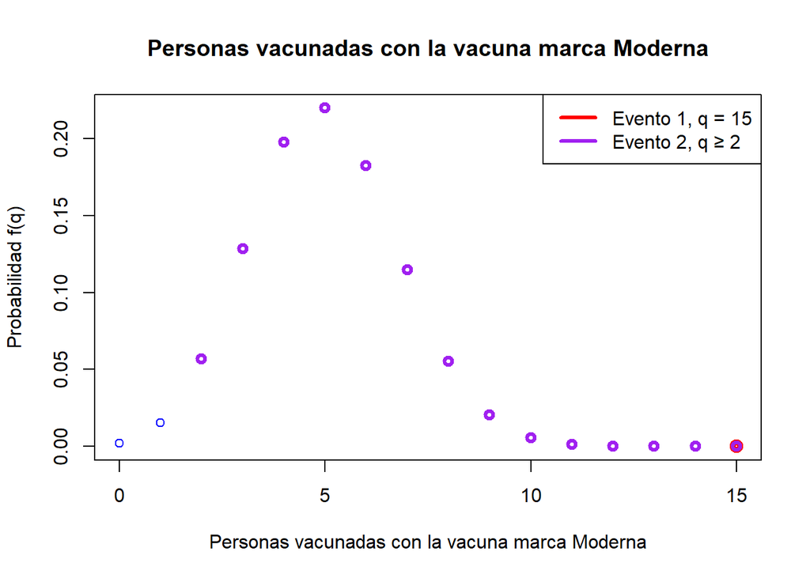

```r
n=15 # Muestra
N=100 # Moderna / Tipo 1
M=200 # Pfizer / Tipo 2
x<-seq(0,n,1)
q1=15 # Cantidad de interes del ejercicio 1
q2=1 # Cantidad de interes del ejercicio 2 (Tomando en cuenta que F(x≥2)=1-F(X<1))
q3a=7 # Cantidad inicial de interes del ejercicio 3
q3b=10 # Cantidad final de interes del ejercicio 3

plot(x,dhyper(x,N,M,n),main = "Personas vacunadas con la vacuna marca Moderna",ylab = "Probabilidad f(q)", xlab = "Personas vacunadas con la vacuna marca Moderna",col="blue")
#Ejercicio 1
points(q1,dhyper(q1,N,M,n),col="red",lwd=5)
#Ejercicio 2
x<-seq(2,15,1)
points(x,dhyper(x,N,M,n),col="purple",lwd=3)
# Simbologia
legend("topright", legend = c(paste0("Evento 1, q = ",q1),paste0("Evento 2, q ≥ ",q2+1)),lwd = 3, col = c("red","purple"))
```

**Grafica tipo 2**

[figure not shown]

```r
n=15 # Muestra
N=100 # Moderna / Tipo 1
M=200 # Pfizer / Tipo 2
x<-seq(0,n,1)
q1=15 # Cantidad de interes del ejercicio 1
q2=1 # Cantidad de interes del ejercicio 2 (Tomando en cuenta que F(x≥2)=1-F(X<1))
q3a=7 # Cantidad inicial de interes del ejercicio 3
q3b=10 # Cantidad final de interes del ejercicio 3

plot(x,dhyper(x,M,N,n),main = "Personas vacunadas con la vacuna marca Pfzier",ylab = "Probabilidad f(q)", xlab = "Personas vacunadas con la vacuna marca Pfzier",col="blue")
#Ejercicio 3
x3<-seq(q3a+1,q3b-1,1)
points(x3,dhyper(x3,M,N,n),col="cyan",lwd=3)
# Simbologia
legend("topleft", legend = c(paste0("Evento 3, ",q3a," > q > ",q3b)),lwd = 3, col = c("cyan"))
```